# Risk Factor Analysis

## Outcome Variable

**Outcome Variable:** stunted

## Predictor Variables

**Intervention Variable:** pers_wast

**Adjustment Set:**

- arm
- sex
- W_mage
- meducyrs
- W_mhtcm
- month
- brthmon
- delta_W_mage
- delta_meducyrs
- delta_W_mhtcm
- delta_month
- delta_brthmon

## Stratifying Variables

The analysis was stratified on these variable(s):

- agecat
- studyid
- country

## Data Summary

| agecat | studyid | country | pers_wast | stunted | n_cell | n |
| --- | --- | --- | --- | --- | --- | --- |
| Birth | ki0047075b-MAL-ED | BANGLADESH | 0 | 0 | 203 | 255 |
| Birth | ki0047075b-MAL-ED | BANGLADESH | 0 | 1 | 43 | 255 |
| Birth | ki0047075b-MAL-ED | BANGLADESH | 1 | 0 | 7 | 255 |
| Birth | ki0047075b-MAL-ED | BANGLADESH | 1 | 1 | 2 | 255 |
| 6 months | ki0047075b-MAL-ED | BANGLADESH | 0 | 0 | 190 | 241 |
| 6 months | ki0047075b-MAL-ED | BANGLADESH | 0 | 1 | 44 | 241 |
| 6 months | ki0047075b-MAL-ED | BANGLADESH | 1 | 0 | 6 | 241 |
| 6 months | ki0047075b-MAL-ED | BANGLADESH | 1 | 1 | 1 | 241 |
| 24 months | ki0047075b-MAL-ED | BANGLADESH | 0 | 0 | 109 | 212 |
| 24 months | ki0047075b-MAL-ED | BANGLADESH | 0 | 1 | 97 | 212 |
| 24 months | ki0047075b-MAL-ED | BANGLADESH | 1 | 0 | 5 | 212 |
| 24 months | ki0047075b-MAL-ED | BANGLADESH | 1 | 1 | 1 | 212 |
| Birth | ki0047075b-MAL-ED | BRAZIL | 0 | 0 | 170 | 191 |
| Birth | ki0047075b-MAL-ED | BRAZIL | 0 | 1 | 21 | 191 |
| 6 months | ki0047075b-MAL-ED | BRAZIL | 0 | 0 | 202 | 209 |
| 6 months | ki0047075b-MAL-ED | BRAZIL | 0 | 1 | 6 | 209 |
| 6 months | ki0047075b-MAL-ED | BRAZIL | 1 | 0 | 1 | 209 |
| 6 months | ki0047075b-MAL-ED | BRAZIL | 1 | 1 | 0 | 209 |
| 24 months | ki0047075b-MAL-ED | BRAZIL | 0 | 0 | 162 | 169 |
| 24 months | ki0047075b-MAL-ED | BRAZIL | 0 | 1 | 6 | 169 |
| 24 months | ki0047075b-MAL-ED | BRAZIL | 1 | 0 | 1 | 169 |
| 24 months | ki0047075b-MAL-ED | BRAZIL | 1 | 1 | 0 | 169 |
| Birth | ki0047075b-MAL-ED | INDIA | 0 | 0 | 159 | 206 |
| Birth | ki0047075b-MAL-ED | INDIA | 0 | 1 | 32 | 206 |
| Birth | ki0047075b-MAL-ED | INDIA | 1 | 0 | 14 | 206 |
| Birth | ki0047075b-MAL-ED | INDIA | 1 | 1 | 1 | 206 |
| 6 months | ki0047075b-MAL-ED | INDIA | 0 | 0 | 176 | 236 |
| 6 months | ki0047075b-MAL-ED | INDIA | 0 | 1 | 42 | 236 |
| 6 months | ki0047075b-MAL-ED | INDIA | 1 | 0 | 14 | 236 |
| 6 months | ki0047075b-MAL-ED | INDIA | 1 | 1 | 4 | 236 |

[output cut: 142 more lines]

The following strata were considered:

- agecat: 24 months, studyid: ki0047075b-MAL-ED, country: BANGLADESH
- agecat: 24 months, studyid: ki0047075b-MAL-ED, country: BRAZIL
- agecat: 24 months, studyid: ki0047075b-MAL-ED, country: INDIA
- agecat: 24 months, studyid: ki0047075b-MAL-ED, country: NEPAL
- agecat: 24 months, studyid: ki0047075b-MAL-ED, country: PERU
- agecat: 24 months, studyid: ki0047075b-MAL-ED, country: SOUTH AFRICA
- agecat: 24 months, studyid: ki0047075b-MAL-ED, country: TANZANIA, UNITED REPUBLIC OF
- agecat: 24 months, studyid: ki1000108-CMC-V-BCS-2002, country: INDIA
- agecat: 24 months, studyid: ki1000108-IRC, country: INDIA
- agecat: 24 months, studyid: ki1017093b-PROVIDE, country: BANGLADESH
- agecat: 24 months, studyid: ki1066203-TanzaniaChild2, country: TANZANIA, UNITED REPUBLIC OF
- agecat: 24 months, studyid: ki1101329-Keneba, country: GAMBIA
- agecat: 24 months, studyid: ki1113344-GMS-Nepal, country: NEPAL
- agecat: 24 months, studyid: ki1114097-CMIN, country: BANGLADESH
- agecat: 24 months, studyid: ki1114097-CMIN, country: PERU
- agecat: 24 months, studyid: ki1114097-CONTENT, country: PERU
- agecat: 6 months, studyid: ki0047075b-MAL-ED, country: BANGLADESH
- agecat: 6 months, studyid: ki0047075b-MAL-ED, country: BRAZIL
- agecat: 6 months, studyid: ki0047075b-MAL-ED, country: INDIA
- agecat: 6 months, studyid: ki0047075b-MAL-ED, country: NEPAL
- agecat: 6 months, studyid: ki0047075b-MAL-ED, country: PERU
- agecat: 6 months, studyid: ki0047075b-MAL-ED, country: SOUTH AFRICA
- agecat: 6 months, studyid: ki0047075b-MAL-ED, country: TANZANIA, UNITED REPUBLIC OF
- agecat: 6 months, studyid: ki1000108-CMC-V-BCS-2002, country: INDIA
- agecat: 6 months, studyid: ki1000108-IRC, country: INDIA
- agecat: 6 months, studyid: ki1000109-EE, country: PAKISTAN
- agecat: 6 months, studyid: ki1000109-ResPak, country: PAKISTAN
- agecat: 6 months, studyid: ki1017093b-PROVIDE, country: BANGLADESH
- agecat: 6 months, studyid: ki1066203-TanzaniaChild2, country: TANZANIA, UNITED REPUBLIC OF
- agecat: 6 months, studyid: ki1101329-Keneba, country: GAMBIA
- agecat: 6 months, studyid: ki1112895-Guatemala BSC, country: GUATEMALA
- agecat: 6 months, studyid: ki1113344-GMS-Nepal, country: NEPAL
- agecat: 6 months, studyid: ki1114097-CMIN, country: BANGLADESH
- agecat: 6 months, studyid: ki1114097-CMIN, country: PERU
- agecat: 6 months, studyid: ki1114097-CONTENT, country: PERU
- agecat: Birth, studyid: ki0047075b-MAL-ED, country: BANGLADESH
- agecat: Birth, studyid: ki0047075b-MAL-ED, country: BRAZIL
- agecat: Birth, studyid: ki0047075b-MAL-ED, country: INDIA
- agecat: Birth, studyid: ki0047075b-MAL-ED, country: NEPAL
- agecat: Birth, studyid: ki0047075b-MAL-ED, country: PERU
- agecat: Birth, studyid: ki0047075b-MAL-ED, country: SOUTH AFRICA
- agecat: Birth, studyid: ki0047075b-MAL-ED, country: TANZANIA, UNITED REPUBLIC OF
- agecat: Birth, studyid: ki1000108-CMC-V-BCS-2002, country: INDIA
- agecat: Birth, studyid: ki1000108-IRC, country: INDIA
- agecat: Birth, studyid: ki1000109-EE, country: PAKISTAN
- agecat: Birth, studyid: ki1000109-ResPak, country: PAKISTAN
- agecat: Birth, studyid: ki1101329-Keneba, country: GAMBIA
- agecat: Birth, studyid: ki1114097-CMIN, country: BANGLADESH
- agecat: Birth, studyid: ki1114097-CMIN, country: PERU
- agecat: Birth, studyid: ki1114097-CONTENT, country: PERU

### Dropped Strata

Some strata were dropped due to rare outcomes:

- agecat: Birth, studyid: ki0047075b-MAL-ED, country: BANGLADESH
- agecat: 6 months, studyid: ki0047075b-MAL-ED, country: BANGLADESH
- agecat: 24 months, studyid: ki0047075b-MAL-ED, country: BANGLADESH
- agecat: 6 months, studyid: ki0047075b-MAL-ED, country: BRAZIL
- agecat: 24 months, studyid: ki0047075b-MAL-ED, country: BRAZIL
- agecat: Birth, studyid: ki0047075b-MAL-ED, country: INDIA
- agecat: 6 months, studyid: ki0047075b-MAL-ED, country: INDIA
- agecat: 24 months, studyid: ki0047075b-MAL-ED, country: INDIA
- agecat: 6 months, studyid: ki0047075b-MAL-ED, country: NEPAL
- agecat: 24 months, studyid: ki0047075b-MAL-ED, country: NEPAL
- agecat: Birth, studyid: ki0047075b-MAL-ED, country: NEPAL
- agecat: Birth, studyid: ki0047075b-MAL-ED, country: SOUTH AFRICA
- agecat: 6 months, studyid: ki0047075b-MAL-ED, country: SOUTH AFRICA
- agecat: 24 months, studyid: ki0047075b-MAL-ED, country: SOUTH AFRICA
- agecat: Birth, studyid: ki1000109-EE, country: PAKISTAN
- agecat: Birth, studyid: ki1000109-ResPak, country: PAKISTAN
- agecat: 24 months, studyid: ki1017093b-PROVIDE, country: BANGLADESH
- agecat: 6 months, studyid: ki1066203-TanzaniaChild2, country: TANZANIA, UNITED REPUBLIC OF
- agecat: 24 months, studyid: ki1066203-TanzaniaChild2, country: TANZANIA, UNITED REPUBLIC OF
- agecat: Birth, studyid: ki1101329-Keneba, country: GAMBIA
- agecat: 6 months, studyid: ki1112895-Guatemala BSC, country: GUATEMALA
- agecat: 6 months, studyid: ki1114097-CMIN, country: BANGLADESH
- agecat: 24 months, studyid: ki1114097-CMIN, country: BANGLADESH
- agecat: Birth, studyid: ki1114097-CMIN, country: BANGLADESH
- agecat: 24 months, studyid: ki1114097-CMIN, country: PERU
- agecat: Birth, studyid: ki1114097-CONTENT, country: PERU

## Methods Detail

We’re interested in the causal parameters $E[Y_a]$ for all values of $a \in \mathcal{A}$. These parameters represent the mean outcome if, possibly contrary to fact, we intervened to set all units to have $A=a$. Under the randomization and positivity assumptions, these are identified by the statistical parameters $\psi_a=E_W[E_{Y|A,W}(Y|A=a,W)]$. In addition, we’re interested in the mean of $Y$, $E[Y]$ under no intervention (the observed mean). We will estimate these parameters by using SuperLearner to fit the relevant likelihood factors – $E_{Y|A,W}(Y|A=a,W)$ and $p(A=a|W)$, and then updating our likelihood fit using a joint TMLE.

For unadjusted analyses ($W=\{\}$), initial likelihoods were estimated using Lrnr_glm to estimate the simple $E(Y|A)$ and Lrnr_mean to estimate $p(A)$. For adjusted analyses, a small library containing Lrnr_glmnet, Lrnr_xgboost, and Lrnr_mean was used.

Having estimated these parameters, we will then use the delta method to estimate relative risks and attributable risks relative to a prespecified baseline level of $A$.

[output not shown]

# Results Detail

## Results Plots

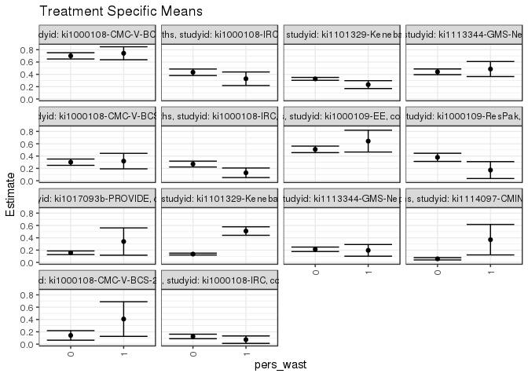

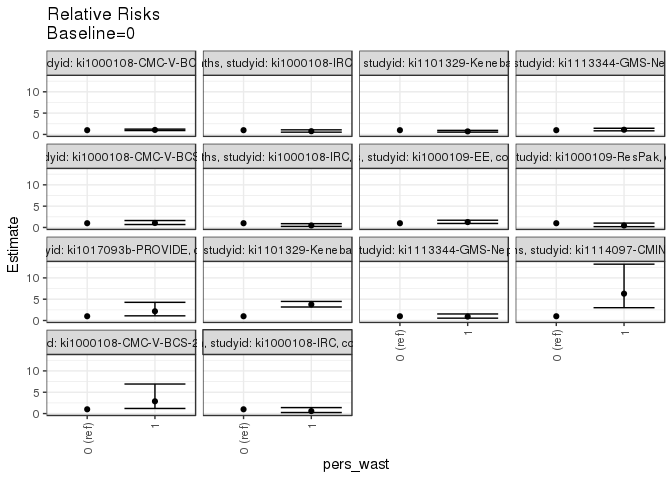

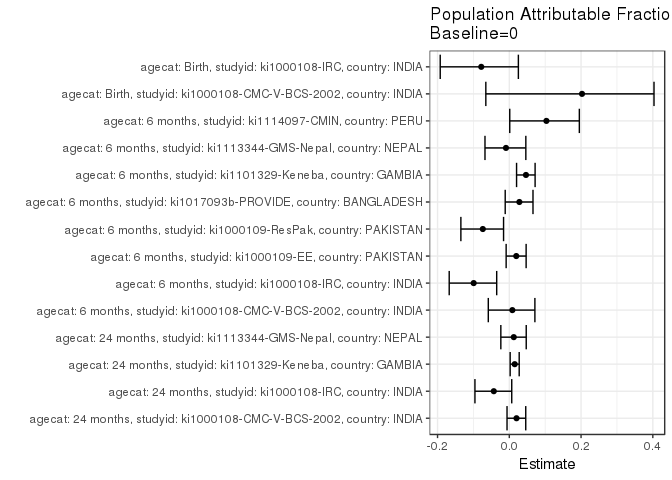

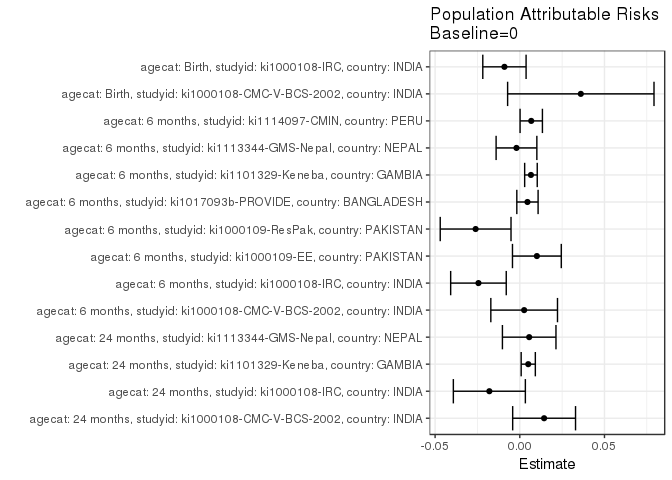

## Results Table

### Parameter: TSM

| agecat | studyid | country | intervention_level | baseline_level | estimate | ci_lower | ci_upper |
| --- | --- | --- | --- | --- | --- | --- | --- |
| Birth | ki1000108-CMC-V-BCS-2002 | INDIA | 0 | NA | 0.1417476 | 0.0642044 | 0.2192908 |
| Birth | ki1000108-CMC-V-BCS-2002 | INDIA | 1 | NA | 0.4072943 | 0.1260299 | 0.6885587 |
| Birth | ki1000108-IRC | INDIA | 0 | NA | 0.1250416 | 0.0887518 | 0.1613314 |
| Birth | ki1000108-IRC | INDIA | 1 | NA | 0.0725988 | 0.0123554 | 0.1328421 |
| 6 months | ki1000108-CMC-V-BCS-2002 | INDIA | 0 | NA | 0.3006966 | 0.2498784 | 0.3515148 |
| 6 months | ki1000108-CMC-V-BCS-2002 | INDIA | 1 | NA | 0.3184562 | 0.1924334 | 0.4444791 |
| 6 months | ki1000108-IRC | INDIA | 0 | NA | 0.2701022 | 0.2226744 | 0.3175301 |
| 6 months | ki1000108-IRC | INDIA | 1 | NA | 0.1284106 | 0.0505968 | 0.2062244 |
| 6 months | ki1000109-EE | PAKISTAN | 0 | NA | 0.5087268 | 0.4558292 | 0.5616243 |
| 6 months | ki1000109-EE | PAKISTAN | 1 | NA | 0.6428308 | 0.4655967 | 0.8200649 |
| 6 months | ki1000109-ResPak | PAKISTAN | 0 | NA | 0.3792677 | 0.3128810 | 0.4456543 |
| 6 months | ki1000109-ResPak | PAKISTAN | 1 | NA | 0.1725155 | 0.0353770 | 0.3096539 |
| 6 months | ki1017093b-PROVIDE | BANGLADESH | 0 | NA | 0.1567076 | 0.1268883 | 0.1865269 |
| 6 months | ki1017093b-PROVIDE | BANGLADESH | 1 | NA | 0.3389920 | 0.1172281 | 0.5607559 |
| 6 months | ki1101329-Keneba | GAMBIA | 0 | NA | 0.1353632 | 0.1204293 | 0.1502971 |
| 6 months | ki1101329-Keneba | GAMBIA | 1 | NA | 0.5096659 | 0.4407859 | 0.5785459 |
| 6 months | ki1113344-GMS-Nepal | NEPAL | 0 | NA | 0.2133207 | 0.1772962 | 0.2493452 |
| 6 months | ki1113344-GMS-Nepal | NEPAL | 1 | NA | 0.1960297 | 0.1010038 | 0.2910557 |
| 6 months | ki1114097-CMIN | PERU | 0 | NA | 0.0586253 | 0.0400205 | 0.0772302 |
| 6 months | ki1114097-CMIN | PERU | 1 | NA | 0.3692188 | 0.1218571 | 0.6165804 |
| 24 months | ki1000108-CMC-V-BCS-2002 | INDIA | 0 | NA | 0.7003151 | 0.6495075 | 0.7511226 |
| 24 months | ki1000108-CMC-V-BCS-2002 | INDIA | 1 | NA | 0.7423869 | 0.6372660 | 0.8475077 |
| 24 months | ki1000108-IRC | INDIA | 0 | NA | 0.4336159 | 0.3807981 | 0.4864338 |
| 24 months | ki1000108-IRC | INDIA | 1 | NA | 0.3286253 | 0.2184610 | 0.4387897 |
| 24 months | ki1101329-Keneba | GAMBIA | 0 | NA | 0.3268436 | 0.3033219 | 0.3503653 |
| 24 months | ki1101329-Keneba | GAMBIA | 1 | NA | 0.2336929 | 0.1697687 | 0.2976171 |
| 24 months | ki1113344-GMS-Nepal | NEPAL | 0 | NA | 0.4413395 | 0.3950044 | 0.4876746 |
| 24 months | ki1113344-GMS-Nepal | NEPAL | 1 | NA | 0.4864254 | 0.3642945 | 0.6085564 |

### Parameter: E(Y)

| agecat | studyid | country | intervention_level | baseline_level | estimate | ci_lower | ci_upper |
| --- | --- | --- | --- | --- | --- | --- | --- |
| Birth | ki1000108-CMC-V-BCS-2002 | INDIA | NA | NA | 0.1777778 | 0.0983474 | 0.2572081 |
| Birth | ki1000108-IRC | INDIA | NA | NA | 0.1159794 | 0.0840777 | 0.1478811 |
| 6 months | ki1000108-CMC-V-BCS-2002 | INDIA | NA | NA | 0.3032787 | 0.2561210 | 0.3504363 |
| 6 months | ki1000108-IRC | INDIA | NA | NA | 0.2457002 | 0.2038248 | 0.2875757 |
| 6 months | ki1000109-EE | PAKISTAN | NA | NA | 0.5188172 | 0.4679751 | 0.5696593 |
| 6 months | ki1000109-ResPak | PAKISTAN | NA | NA | 0.3531915 | 0.2919518 | 0.4144312 |
| 6 months | ki1017093b-PROVIDE | BANGLADESH | NA | NA | 0.1612350 | 0.1313580 | 0.1911120 |
| 6 months | ki1101329-Keneba | GAMBIA | NA | NA | 0.1419543 | 0.1268686 | 0.1570400 |
| 6 months | ki1113344-GMS-Nepal | NEPAL | NA | NA | 0.2113677 | 0.1776128 | 0.2451225 |
| 6 months | ki1114097-CMIN | PERU | NA | NA | 0.0653907 | 0.0460250 | 0.0847565 |
| 24 months | ki1000108-CMC-V-BCS-2002 | INDIA | NA | NA | 0.7146739 | 0.6684741 | 0.7608737 |
| 24 months | ki1000108-IRC | INDIA | NA | NA | 0.4156479 | 0.3678270 | 0.4634689 |
| 24 months | ki1101329-Keneba | GAMBIA | NA | NA | 0.3318414 | 0.3084975 | 0.3551853 |
| 24 months | ki1113344-GMS-Nepal | NEPAL | NA | NA | 0.4468938 | 0.4032281 | 0.4905594 |

### Parameter: RR

| agecat | studyid | country | intervention_level | baseline_level | estimate | ci_lower | ci_upper |
| --- | --- | --- | --- | --- | --- | --- | --- |
| Birth | ki1000108-CMC-V-BCS-2002 | INDIA | 0 | 0 | 1.0000000 | 1.0000000 | 1.0000000 |
| Birth | ki1000108-CMC-V-BCS-2002 | INDIA | 1 | 0 | 2.8733781 | 1.1933399 | 6.9186509 |
| Birth | ki1000108-IRC | INDIA | 0 | 0 | 1.0000000 | 1.0000000 | 1.0000000 |
| Birth | ki1000108-IRC | INDIA | 1 | 0 | 0.5805966 | 0.2412200 | 1.3974480 |
| 6 months | ki1000108-CMC-V-BCS-2002 | INDIA | 0 | 0 | 1.0000000 | 1.0000000 | 1.0000000 |
| 6 months | ki1000108-CMC-V-BCS-2002 | INDIA | 1 | 0 | 1.0590616 | 0.6888310 | 1.6282825 |
| 6 months | ki1000108-IRC | INDIA | 0 | 0 | 1.0000000 | 1.0000000 | 1.0000000 |
| 6 months | ki1000108-IRC | INDIA | 1 | 0 | 0.4754148 | 0.2532531 | 0.8924636 |
| 6 months | ki1000109-EE | PAKISTAN | 0 | 0 | 1.0000000 | 1.0000000 | 1.0000000 |
| 6 months | ki1000109-EE | PAKISTAN | 1 | 0 | 1.2636072 | 0.9411309 | 1.6965792 |
| 6 months | ki1000109-ResPak | PAKISTAN | 0 | 0 | 1.0000000 | 1.0000000 | 1.0000000 |
| 6 months | ki1000109-ResPak | PAKISTAN | 1 | 0 | 0.4548647 | 0.2015522 | 1.0265423 |
| 6 months | ki1017093b-PROVIDE | BANGLADESH | 0 | 0 | 1.0000000 | 1.0000000 | 1.0000000 |
| 6 months | ki1017093b-PROVIDE | BANGLADESH | 1 | 0 | 2.1632141 | 1.0981498 | 4.2612540 |
| 6 months | ki1101329-Keneba | GAMBIA | 0 | 0 | 1.0000000 | 1.0000000 | 1.0000000 |
| 6 months | ki1101329-Keneba | GAMBIA | 1 | 0 | 3.7651727 | 3.1671966 | 4.4760486 |
| 6 months | ki1113344-GMS-Nepal | NEPAL | 0 | 0 | 1.0000000 | 1.0000000 | 1.0000000 |
| 6 months | ki1113344-GMS-Nepal | NEPAL | 1 | 0 | 0.9189438 | 0.5500462 | 1.5352489 |
| 6 months | ki1114097-CMIN | PERU | 0 | 0 | 1.0000000 | 1.0000000 | 1.0000000 |
| 6 months | ki1114097-CMIN | PERU | 1 | 0 | 6.2979410 | 3.0008372 | 13.2176650 |
| 24 months | ki1000108-CMC-V-BCS-2002 | INDIA | 0 | 0 | 1.0000000 | 1.0000000 | 1.0000000 |
| 24 months | ki1000108-CMC-V-BCS-2002 | INDIA | 1 | 0 | 1.0600755 | 0.9042332 | 1.2427769 |
| 24 months | ki1000108-IRC | INDIA | 0 | 0 | 1.0000000 | 1.0000000 | 1.0000000 |
| 24 months | ki1000108-IRC | INDIA | 1 | 0 | 0.7578719 | 0.5305146 | 1.0826654 |
| 24 months | ki1101329-Keneba | GAMBIA | 0 | 0 | 1.0000000 | 1.0000000 | 1.0000000 |
| 24 months | ki1101329-Keneba | GAMBIA | 1 | 0 | 0.7149992 | 0.5398716 | 0.9469360 |
| 24 months | ki1113344-GMS-Nepal | NEPAL | 0 | 0 | 1.0000000 | 1.0000000 | 1.0000000 |
| 24 months | ki1113344-GMS-Nepal | NEPAL | 1 | 0 | 1.1021570 | 0.8405129 | 1.4452487 |

### Parameter: PAR

| agecat | studyid | country | intervention_level | baseline_level | estimate | ci_lower | ci_upper |
| --- | --- | --- | --- | --- | --- | --- | --- |
| Birth | ki1000108-CMC-V-BCS-2002 | INDIA | 0 | NA | 0.0360302 | -0.0071844 | 0.0792449 |
| Birth | ki1000108-IRC | INDIA | 0 | NA | -0.0090623 | -0.0218444 | 0.0037199 |
| 6 months | ki1000108-CMC-V-BCS-2002 | INDIA | 0 | NA | 0.0025821 | -0.0170975 | 0.0222617 |
| 6 months | ki1000108-IRC | INDIA | 0 | NA | -0.0244020 | -0.0408116 | -0.0079924 |
| 6 months | ki1000109-EE | PAKISTAN | 0 | NA | 0.0100904 | -0.0043160 | 0.0244969 |
| 6 months | ki1000109-ResPak | PAKISTAN | 0 | NA | -0.0260762 | -0.0469750 | -0.0051774 |
| 6 months | ki1017093b-PROVIDE | BANGLADESH | 0 | NA | 0.0045274 | -0.0017534 | 0.0108082 |
| 6 months | ki1101329-Keneba | GAMBIA | 0 | NA | 0.0065911 | 0.0028760 | 0.0103062 |
| 6 months | ki1113344-GMS-Nepal | NEPAL | 0 | NA | -0.0019530 | -0.0139807 | 0.0100747 |
| 6 months | ki1114097-CMIN | PERU | 0 | NA | 0.0067654 | 0.0001667 | 0.0133641 |
| 24 months | ki1000108-CMC-V-BCS-2002 | INDIA | 0 | NA | 0.0143588 | -0.0041971 | 0.0329147 |
| 24 months | ki1000108-IRC | INDIA | 0 | NA | -0.0179680 | -0.0392263 | 0.0032902 |
| 24 months | ki1101329-Keneba | GAMBIA | 0 | NA | 0.0049978 | 0.0008162 | 0.0091794 |
| 24 months | ki1113344-GMS-Nepal | NEPAL | 0 | NA | 0.0055543 | -0.0102527 | 0.0213613 |

### Parameter: PAF

| agecat | studyid | country | intervention_level | baseline_level | estimate | ci_lower | ci_upper |
| --- | --- | --- | --- | --- | --- | --- | --- |
| Birth | ki1000108-CMC-V-BCS-2002 | INDIA | 0 | NA | 0.2026700 | -0.0654242 | 0.4033033 |
| Birth | ki1000108-IRC | INDIA | 0 | NA | -0.0781368 | -0.1925231 | 0.0252776 |
| 6 months | ki1000108-CMC-V-BCS-2002 | INDIA | 0 | NA | 0.0085139 | -0.0585386 | 0.0713191 |
| 6 months | ki1000108-IRC | INDIA | 0 | NA | -0.0993161 | -0.1674844 | -0.0351281 |
| 6 months | ki1000109-EE | PAKISTAN | 0 | NA | 0.0194489 | -0.0087907 | 0.0468981 |
| 6 months | ki1000109-ResPak | PAKISTAN | 0 | NA | -0.0738301 | -0.1349613 | -0.0159916 |
| 6 months | ki1017093b-PROVIDE | BANGLADESH | 0 | NA | 0.0280796 | -0.0114081 | 0.0660256 |
| 6 months | ki1101329-Keneba | GAMBIA | 0 | NA | 0.0464311 | 0.0202521 | 0.0719105 |
| 6 months | ki1113344-GMS-Nepal | NEPAL | 0 | NA | -0.0092400 | -0.0677729 | 0.0460843 |
| 6 months | ki1114097-CMIN | PERU | 0 | NA | 0.1034617 | 0.0012472 | 0.1952153 |
| 24 months | ki1000108-CMC-V-BCS-2002 | INDIA | 0 | NA | 0.0200915 | -0.0063327 | 0.0458218 |
| 24 months | ki1000108-IRC | INDIA | 0 | NA | -0.0432289 | -0.0957712 | 0.0067939 |
| 24 months | ki1101329-Keneba | GAMBIA | 0 | NA | 0.0150609 | 0.0023840 | 0.0275767 |
| 24 months | ki1113344-GMS-Nepal | NEPAL | 0 | NA | 0.0124286 | -0.0235960 | 0.0471854 |